# S&P 500

John Yuill

2021-06-12

## Get S&P 500 data

- Set start date to go back in history earlier than default

```r
## tip: set start date mth before you want data so that you will have mthly returns for full period
## (since there is no return calc for the first mth, by def)
sp500 <- getSymbols(Symbols="^GSPC", from="1969-12-01", auto.assign=FALSE)
head(sp500)
```

```
##            GSPC.Open GSPC.High GSPC.Low GSPC.Close GSPC.Volume GSPC.Adjusted
## 1969-12-01         0     94.47    92.78      93.22     9950000         93.22
## 1969-12-02         0     93.54    91.95      92.65     9940000         92.65
## 1969-12-03         0     93.05    91.25      91.65    11300000         91.65
## 1969-12-04         0     92.45    90.36      91.95    13230000         91.95
## 1969-12-05         0     92.91    91.14      91.73    11150000         91.73
## 1969-12-08         0     92.05    90.29      90.84     9990000         90.84
```

## Take a look

### Price trends

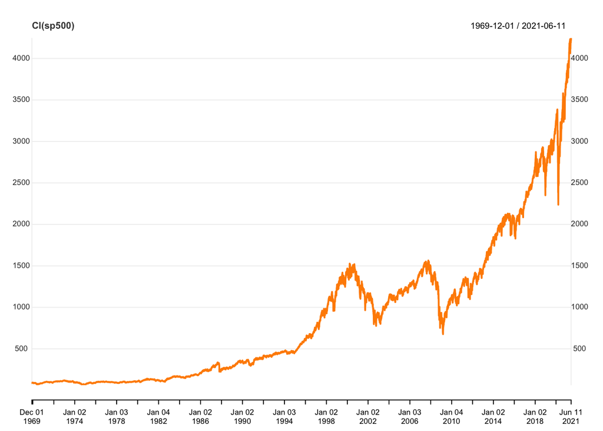

```r
## basic chart_Series from quantmod
chart_Series(Cl(sp500))
```

### Monthly Returns

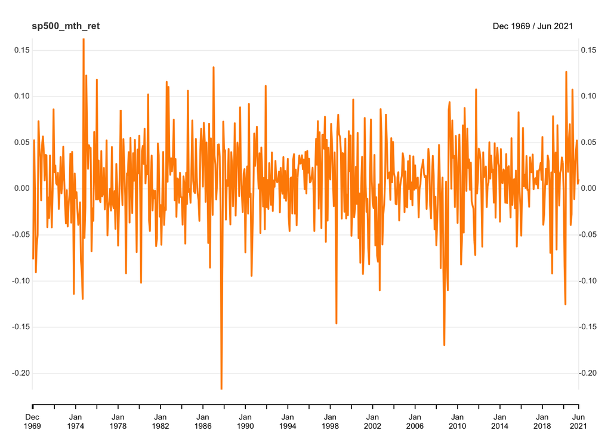

```r
sp500_mth <- to.monthly(sp500)

sp500_mth_ret <- Return.calculate(sp500_mth$sp500.Close)

chart_Series(sp500_mth_ret)
```

## Analyse Monthly Returns

### Summary

```r
## drop first mth, which is NA (by def)
sp500_mth_ret <- sp500_mth_ret[-1,]

sp500_mth_ret_ave <- mean.geometric(sp500_mth_ret)

sp500_mth_ret_stdev <- StdDev(sp500_mth_ret) ## StdDev from PerformanceAnalytics
sp500_mth_min <- min(sp500_mth_ret, na.rm=TRUE)
sp500_mth_max <- max(sp500_mth_ret, na.rm=TRUE)

## annualized return over whole period
sp500_ttl_ann_ret <- Return.annualized(sp500_mth_ret, scale=12)
```

Ave mthly return (geometric): 0.0062193  
Std dev mthly return: 0.0439449  
Worst mthly return: -0.2176304  
Best mthly return: 0.1630469  
Annualized mthly return: 0.0772383

### Distribution

```r
## convert to data frame for easy manage with tidyverse
df_sp500_mth_ret <- as.data.frame(sp500_mth_ret)
df_sp500_mth_ret$mth <- row.names(df_sp500_mth_ret)
row.names(df_sp500_mth_ret) <- seq(1:nrow(df_sp500_mth_ret))
```

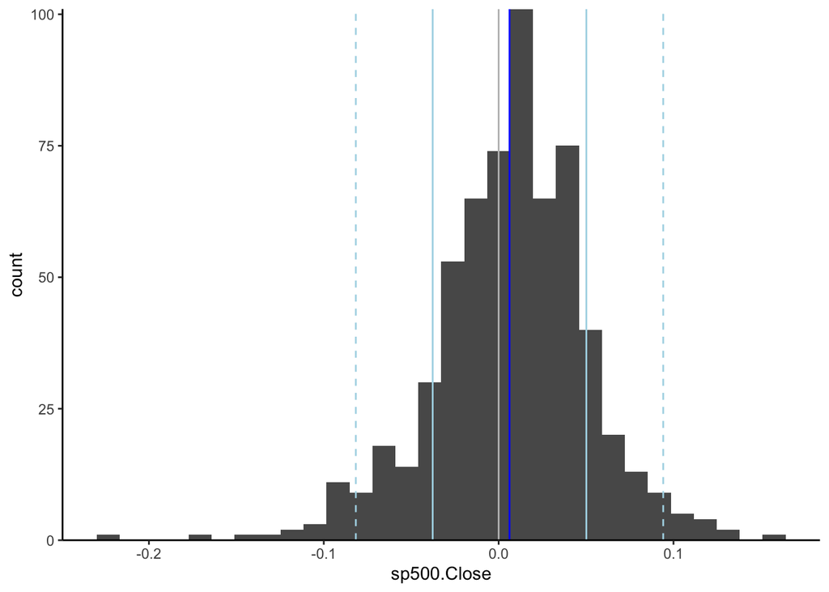

```r
df_sp500_mth_ret %>% ggplot(aes(x=sp500.Close))+geom_histogram()+
  geom_vline(xintercept = 0, color='grey')+
  geom_vline(xintercept=sp500_mth_ret_ave[1], color='blue')+
  geom_vline(xintercept=sp500_mth_ret_ave[1]-sp500_mth_ret_stdev[1], color='lightblue')+
  geom_vline(xintercept=sp500_mth_ret_ave[1]+sp500_mth_ret_stdev[1], color='lightblue')+
  geom_vline(xintercept=sp500_mth_ret_ave[1]-(2*sp500_mth_ret_stdev[1]), color='lightblue', linetype='dashed')+
  geom_vline(xintercept=sp500_mth_ret_ave[1]+(2*sp500_mth_ret_stdev[1]), color='lightblue', linetype='dashed' )+
  scale_y_continuous(expand=c(0,0))+
  theme_classic()
```

#### Skewness / Kurtosis

- Skewness tells us if the distribution is skewed away from normal; negative skewness indicates longer tail on the negative side (left skew)
- Kurtosis tells us if the tails are fatter than normal curve, indicating higher likelihood of results outside the range (in std dev) than are present in normal distribution; highlights volatility

Chart below shows histogram with several reference points:

- density to enhance histogram (darkest blue)
- normal curve overlay to show how well fits normal
- centered normal curve to compare to normal centered on 0 (data is slightly above, which is good)
- rug accentuates density of distribution

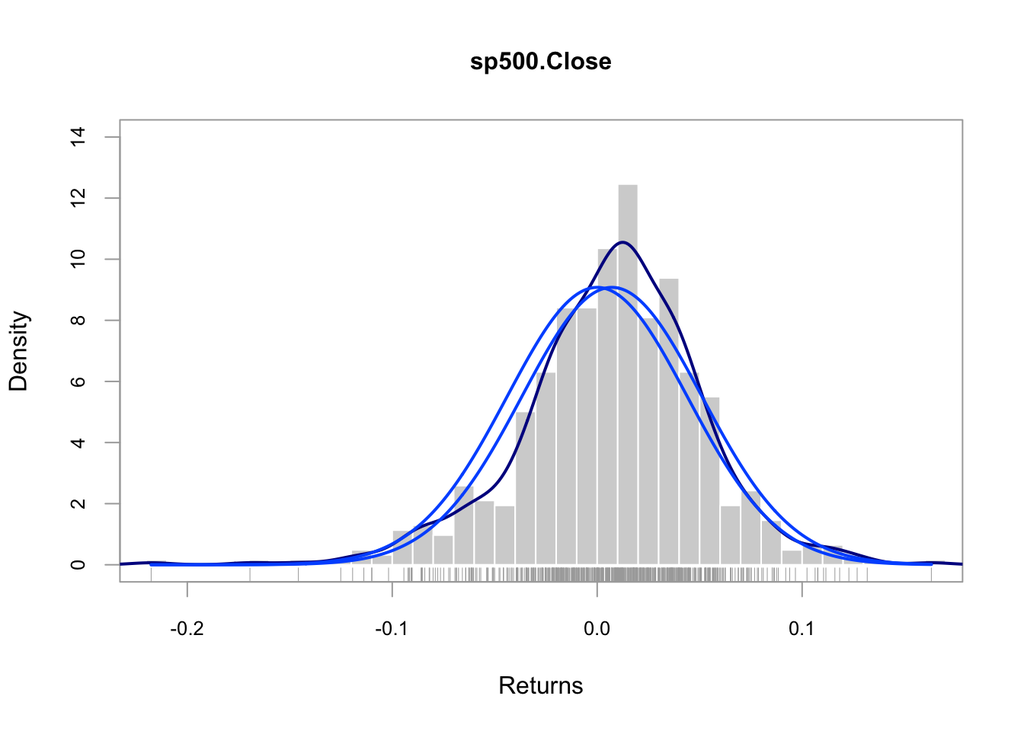

```r
## Histograms from PerformanceAnalytics
# Plot histogram of 2008
chart.Histogram(sp500_mth_ret, methods=c('add.density', 'add.normal', 'add.centered','add.rug'))
```

### Sharpe ratio

- Sharpe ratio identifies how much excess return you are gaining in exchange for risk (compared to risk-free rate)
- works best if data is normally distributed
- ideally want to be above 1: higher the better
- different calc methods with similar but not same results

```r
## set risk free rate for comparison
rfrate <- 0.02 ## annual
sp500_yr <- to.yearly(sp500) ## convert daily to annual
sp500_yr_ret <- Return.calculate(sp500_yr[,4]) ## calculate returns based on annual close
## get ave anual return
sp500_yr_ret_ave <- mean.geometric(sp500_yr_ret)
sp500_yr_ret_ave
```

```
##                sp500.Close
## Geometric Mean   0.0764679
```

```r
## get annual return std dev
sp500_yr_ret_sd <- StdDev(sp500_yr_ret)
sp500_yr_ret_sd
```

```
##            [,1]
## StdDev 0.162595
```

```r
## calc sharpe ratio
## on annual data
sh_ratio <- (sp500_yr_ret_ave-rfrate)/sp500_yr_ret_sd
sh_ratio
```

```
##                sp500.Close
## Geometric Mean   0.3472916
```

```r
## annualized based on mthly data using Performance Analytics
table.AnnualizedReturns(sp500_mth_ret, Rf=rfrate/12, scale=12)
```

```
##                           sp500.Close
## Annualized Return              0.0772
## Annualized Std Dev             0.1522
## Annualized Sharpe (Rf=2%)      0.3679
```

```r
## annualized based on daily data
sp500_ret <- Return.calculate(sp500[,4])
table.AnnualizedReturns(sp500_ret, Rf=rfrate/252, scale=252)
```

```
##                           GSPC.Close
## Annualized Return             0.0769
## Annualized Std Dev            0.1716
## Annualized Sharpe (Rf=2%)     0.3236
```

Doesn’t look good from Sharpe ratio point of view, due to high std dev over time.

## Rolling returns

### Annual 12-mth Returns by Each Month

- Chart shows trailing annualized returns for each month

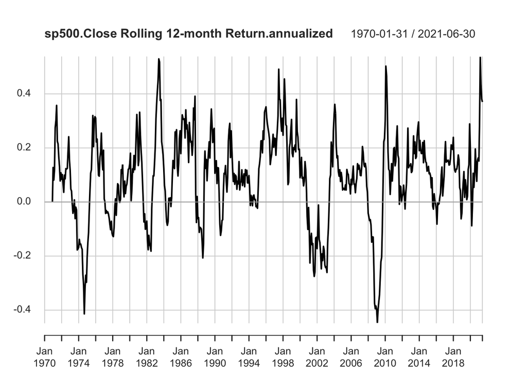

```r
## get mth again but set mth dates to index to last day of mth -> more flexible approach
sp500_mth <- to.monthly(sp500, indexAt='lastof')
sp500_mth_ret <- Return.calculate(sp500_mth[,4], method='discrete')

## get annualized return by month (for width=12)
sp500_mth_ann <- apply.rolling(sp500_mth_ret, width=12, by=1, FUN='Return.annualized')

# Plotting the 12-month rolling annualized return from monthly data
chart.RollingPerformance(R = sp500_mth_ret, width = 12, FUN = "Return.annualized")
```

```r
## convert to data frame for easier operation with tidyverse
df_sp500_mth_ann <- as.data.frame(sp500_mth_ann)
df_sp500_mth_ann$month <- date(row.names(df_sp500_mth_ann))
row.names(df_sp500_mth_ann) <- seq(1:nrow(df_sp500_mth_ann))
df_sp500_mth_ann <- df_sp500_mth_ann %>% rename(
  ann_ret=calcs
) %>% mutate(
  year=year(month)
)

## identify outliers
## define percentiles to use for outliers (could also use std dev)
ret_top <- quantile(df_sp500_mth_ann$ann_ret, 0.95, na.rm=TRUE)
ret_bottom <- quantile(df_sp500_mth_ann$ann_ret, 0.05, na.rm=TRUE)

## filter for outliers defined above
sp500_arTop <- df_sp500_mth_ann %>% filter(ann_ret>=ret_top)
sp500_arBottom <- df_sp500_mth_ann %>% filter(ann_ret<=ret_bottom)


## clean-up data for chart
sp500_tb <- bind_rows(sp500_arTop, sp500_arBottom)
```

- show outliers for magnitude, with yrs in color

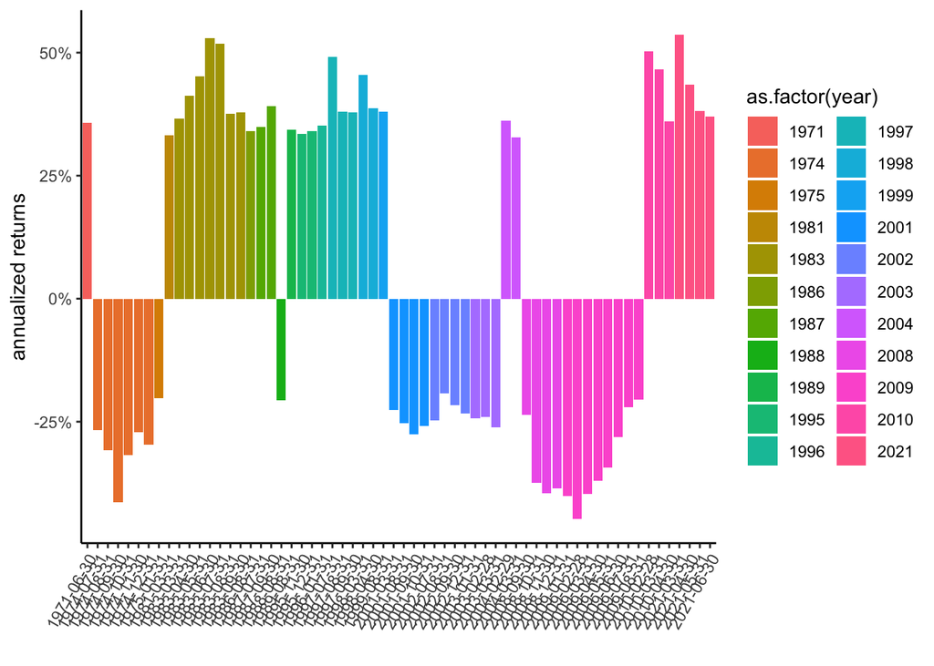

```r
## chart outliers (note: convert 'month' from date to character in order to 'clump' together)
sp500_tb %>% ggplot(aes(x=as.character(month), y=ann_ret, fill=as.factor(year)))+geom_col()+
  scale_y_continuous(labels=percent)+
  theme_classic()+theme(axis.text.x = element_text(vjust=1, hjust=1, angle=60))+
  labs(x="", y="annualized returns")
```

- same data but spread out dates on full scale for perspective

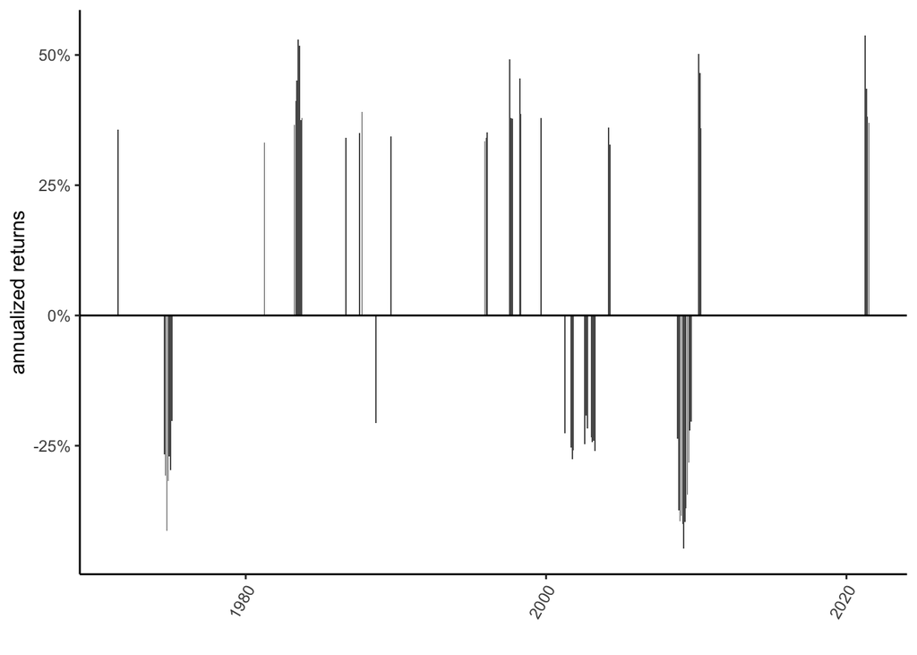

```r
## chart outliers - spread out dates
sp500_tb %>% ggplot(aes(x=month, y=ann_ret))+geom_col()+
  scale_y_continuous(labels=percent)+
  geom_hline(yintercept=0)+
  theme_classic()+theme(axis.text.x = element_text(vjust=1, hjust=1, angle=60))+
  labs(x="", y="annualized returns")
```

- outlying periods tend to be few, far between, short
- more upside than down, and tend to be larger (although shorter than the big downturns)
- downturns tend NOT to follow closely on major upturns

### Distribution

- vertical lines are mean and 2 x std dev

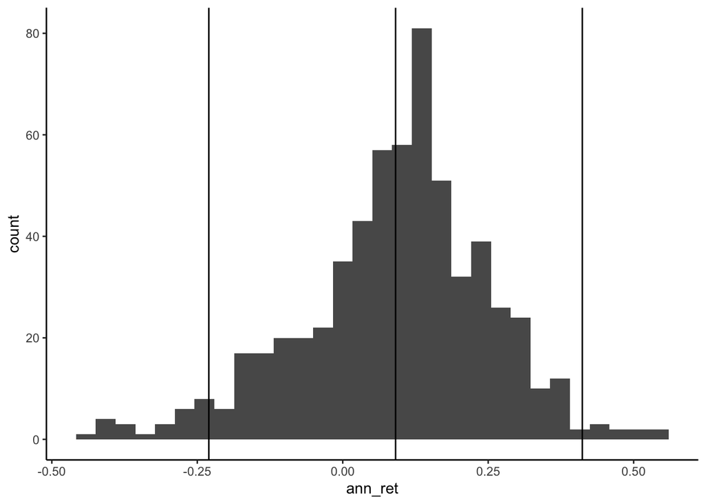

```r
df_sp500_mth_ann %>% ggplot(aes(x=ann_ret))+geom_histogram()+
  geom_vline(xintercept=mean(df_sp500_mth_ann$ann_ret, na.rm=TRUE))+
  geom_vline(xintercept=mean(df_sp500_mth_ann$ann_ret, na.rm=TRUE)-
               (StdDev(df_sp500_mth_ann$ann_ret, na.rm=TRUE)*2))+
  geom_vline(xintercept=mean(df_sp500_mth_ann$ann_ret, na.rm=TRUE)+
               (StdDev(df_sp500_mth_ann$ann_ret, na.rm=TRUE)*2))+
  theme_classic()
```

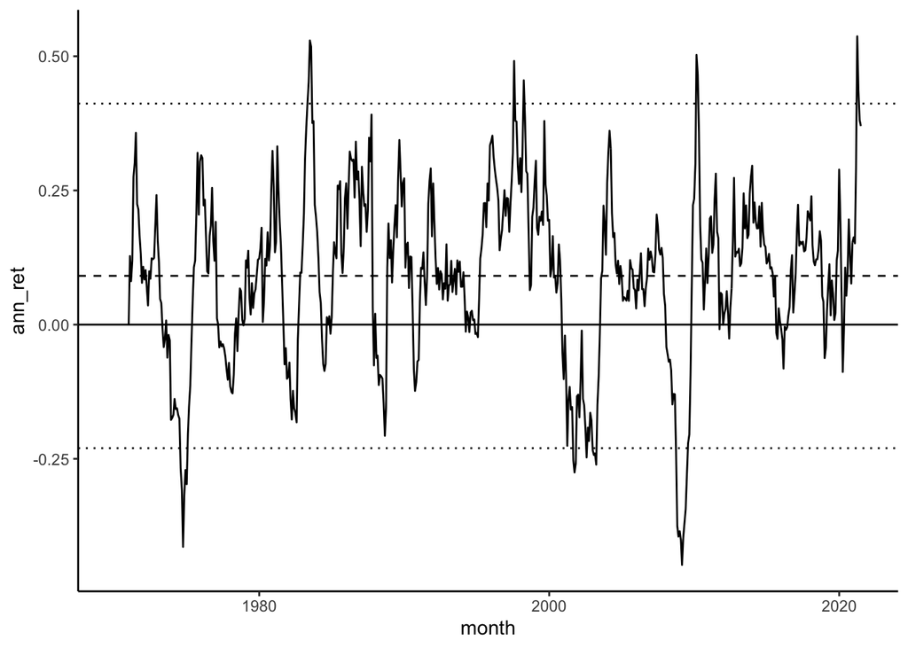

```r
df_sp500_mth_ann %>% ggplot(aes(x=month, y=ann_ret))+geom_line()+
  geom_hline(yintercept=mean(df_sp500_mth_ann$ann_ret, na.rm=TRUE), linetype='dashed')+
  geom_hline(yintercept=mean(df_sp500_mth_ann$ann_ret, na.rm=TRUE)-
               (StdDev(df_sp500_mth_ann$ann_ret, na.rm=TRUE)*2), linetype='dotted')+
  geom_hline(yintercept=mean(df_sp500_mth_ann$ann_ret, na.rm=TRUE)+
               (StdDev(df_sp500_mth_ann$ann_ret, na.rm=TRUE)*2), linetype='dotted')+
  geom_hline(yintercept=0)+
  theme_classic()
```

### Longer term rolling views

- annualized returns by month for 1 yr , 3 yr, 5 yr cycles
- longer periods have less extremes (volatility) and more consistently positive annualized returns

THINK LONG TERM (5+ yrs) and STAY IN THE MARKET!

```r
sp500_roll12 <- apply.rolling(sp500_mth_ret, width=12, by=1, FUN='Return.annualized')
sp500_roll36 <- apply.rolling(sp500_mth_ret, width=36, by=1, FUN='Return.annualized')
sp500_roll60 <- apply.rolling(sp500_mth_ret, width=60, by=1, FUN='Return.annualized')

## combine into single data frame
df_sp500_roll12 <- as.data.frame(sp500_roll12)
df_sp500_roll12 <- df_sp500_roll12 %>% mutate(
  month=date(row.names(df_sp500_roll12))
) %>% rename(
  ann_ret12=calcs
)

df_sp500_roll36 <- as.data.frame(sp500_roll36)
df_sp500_roll36 <- df_sp500_roll36 %>% mutate(
  month=date(row.names(df_sp500_roll36))
) %>% rename(
  ann_ret36=calcs
)
#row.names(df_sp500_roll36) <- seq(1:nrow(df_sp500_roll36))

df_sp500_roll60 <- as.data.frame(sp500_roll60)
df_sp500_roll60 <- df_sp500_roll60 %>% mutate(
  month=date(row.names(df_sp500_roll60))
) %>% rename(
  ann_ret60=calcs
)
#row.names(df_sp500_roll60) <- seq(1:nrow(df_sp500_roll60))

#df_sp500_roll_all <- bind_cols(df_sp500_roll12, df_sp500_roll36, df_sp500_roll60)
df_sp500_roll_all <- full_join(df_sp500_roll12, df_sp500_roll36, by='month')
df_sp500_roll_all <- full_join(df_sp500_roll_all, df_sp500_roll60, by='month')
df_sp500_roll_all <- df_sp500_roll_all %>% select(month, ann_ret12, ann_ret36, ann_ret60)
```

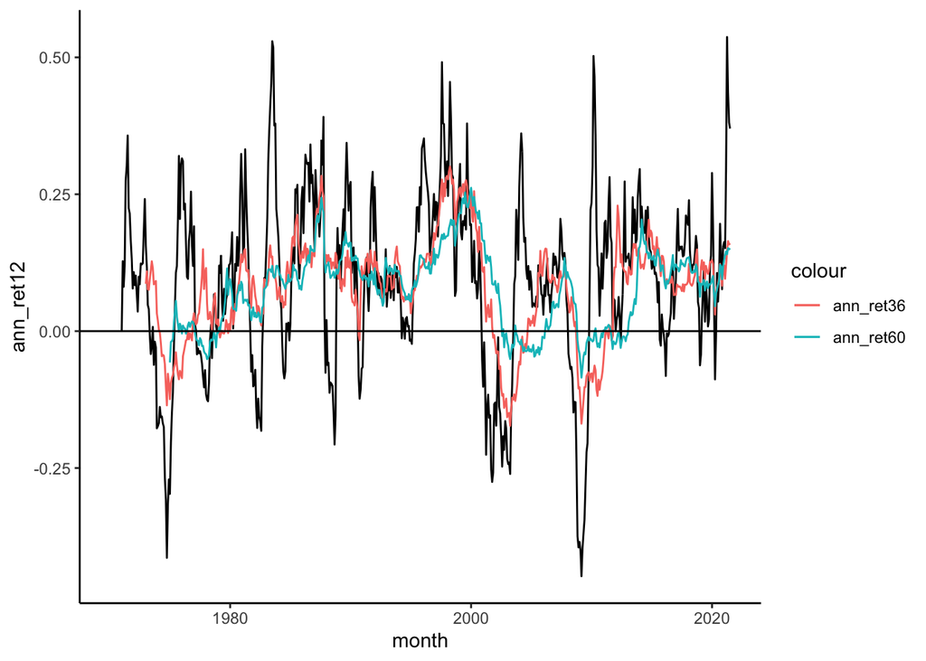

```r
df_sp500_roll_all %>% ggplot(aes(x=month, y=ann_ret12))+geom_line()+
  geom_line(aes(y=ann_ret36, color='ann_ret36'))+
  geom_line(aes(y=ann_ret60, color='ann_ret60'))+
  geom_hline(yintercept = 0)+
  theme_classic()
```

## Focus Specific Period (Window)

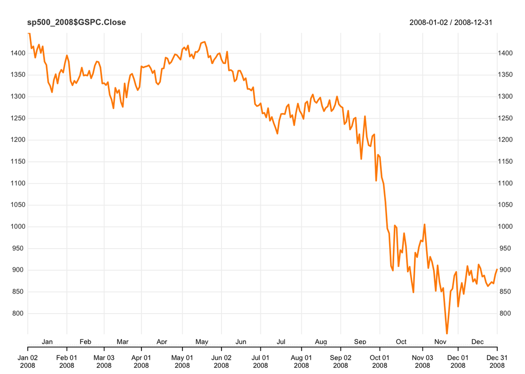

```r
#sp500 <- sp500_2009
sp500_2008 <- sp500["2008-01-01/2008-12-31"]
chart_Series(sp500_2008$GSPC.Close)
```

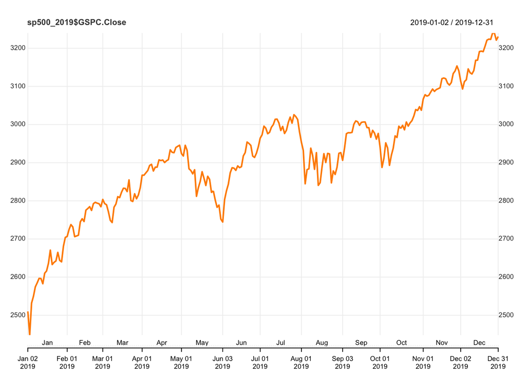

```r
sp500_2019 <- sp500["2019-01-01/2019-12-31"]
chart_Series(sp500_2019$GSPC.Close)
```

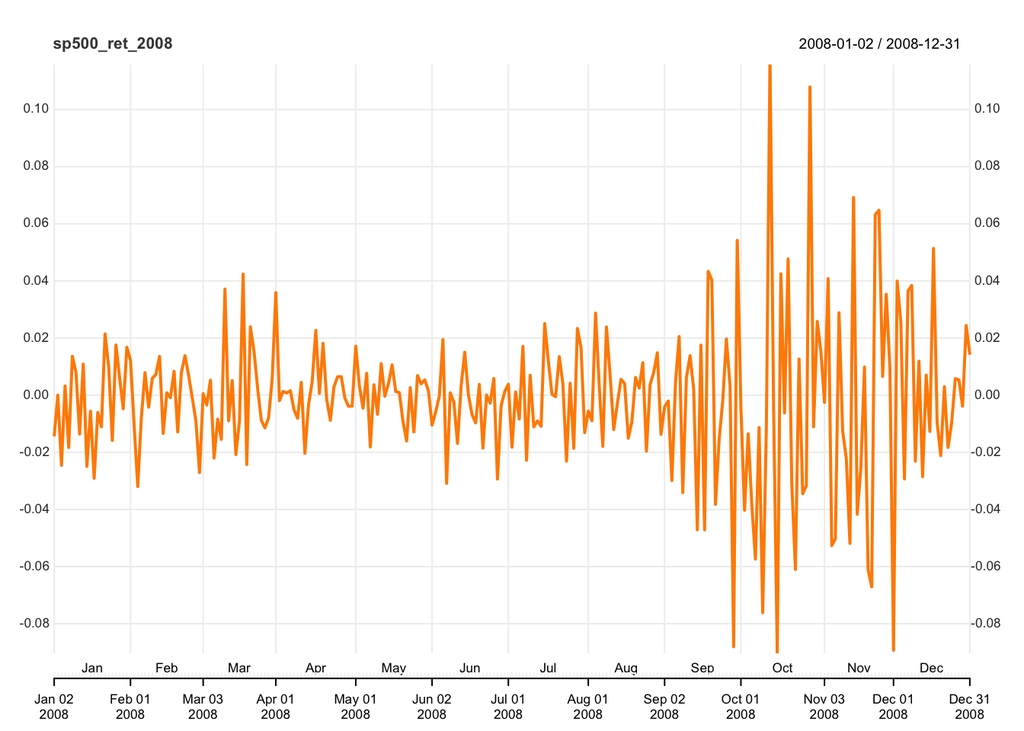

```r
sp500_ret_2008 <- window(sp500_ret, start="2008-01-01", end="2008-12-31")
sp500_ret_2019 <- window(sp500_ret, start="2019-01-01", end="2019-12-31")

chart_Series(sp500_ret_2008)
```

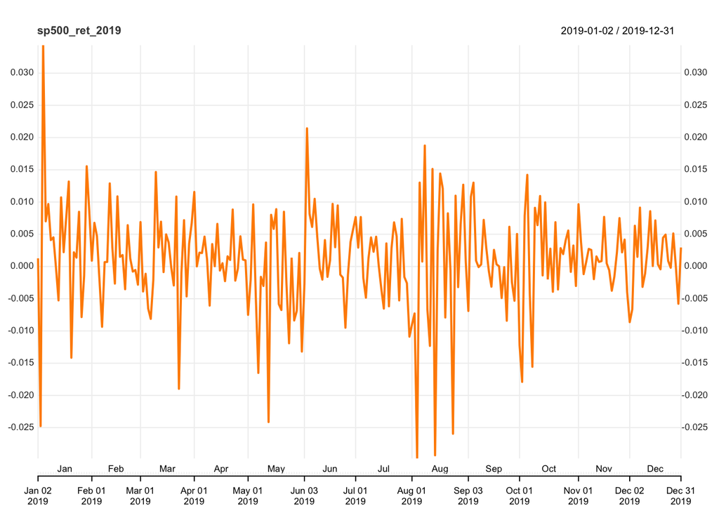

```r
chart_Series(sp500_ret_2019)
```

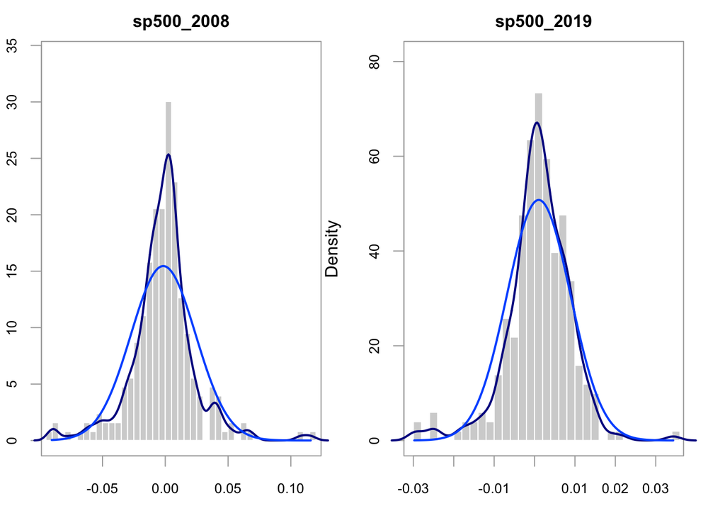

```r
# Plotting settings
par(mfrow = c(1, 2) , mar=c(3, 2, 2, 2))
names(sp500_ret_2008) <- "sp500_2008"
names(sp500_ret_2019) <- "sp500_2019"

## Histograms from PerformanceAnalytics
# Plot histogram of 2008
chart.Histogram(sp500_ret_2008, methods=c('add.density', 'add.normal'))

# Plot histogram of 2014
chart.Histogram(sp500_ret_2019, methods=c('add.density', 'add.normal'))
```

### Skewness and Kurtosis

```r
sk2008 <- skewness(sp500_ret_2008)
sk2019 <- skewness(sp500_ret_2019)

krt2008 <- kurtosis(sp500_ret_2008)
krt2019 <- kurtosis(sp500_ret_2019)
```

Skewness:  
2008: 0.1886251  
2019: -0.5807056

Kurtosis:  
2008: 3.9016886  
2019: 3.2038514